# Project2: SMARTPHONES PRICE PREDICTION

Iker Rosales

2022-12-09

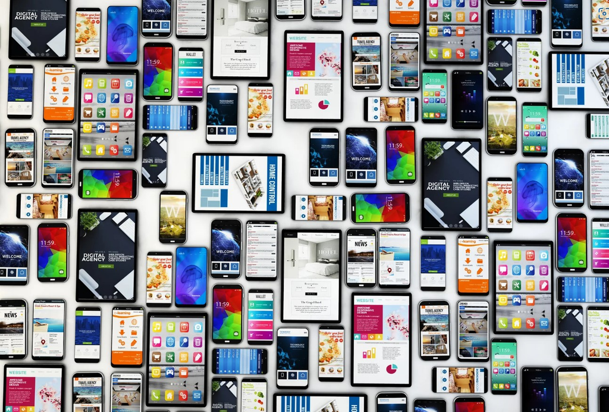

Smatphones Price Prediction. This dataset contains a collection of smartphones with their specifications that contain relevant information for classifiction and regression. The features are described by its own name so it does not worth to explain each of it. Some of them are:

- Storage(GB)
- RAM memory(MB)
- Wi.Fi
- GPS
- Price
- Processors
- SIM slots
- …

The project is going to be centered on the classification and regression of the Price variable. It will be divided in factors in the first part of the project, and it will be numeric in the second part, as it was explained in class.

It is important to remark that the parts 2 and 3 and 4 and 5 are mixed respectively, since it was easier to explain “all in one” to then justify with the predictions.

# DATA PREPROCESSING AND FEATURE EXTRACTION

```r
library(tidyverse)
setwd("~/UC3M/Statistical Learning/project2")

data = read.csv("ndtv_data_final.csv")
glimpse(data)
```

```
## Rows: 1,359
## Columns: 22
## $ X                      <int> 0, 1, 2, 3, 4, 5, 6, 7, 8, 9, 10, 11, 12, 13, 1~
## $ Name                   <chr> "OnePlus 7T Pro McLaren Edition", "Realme X2 Pr~
## $ Brand                  <chr> "OnePlus", "Realme", "Apple", "Apple", "LG", "O~
## $ Model                  <chr> "7T Pro McLaren Edition", "X2 Pro", "iPhone 11 ~
## $ Battery.capacity..mAh. <int> 4085, 4000, 3969, 3110, 4000, 3800, 4085, 4300,~
## $ Screen.size..inches.   <dbl> 6.67, 6.50, 6.50, 6.10, 6.40, 6.55, 6.67, 6.80,~
## $ Touchscreen            <chr> "Yes", "Yes", "Yes", "Yes", "Yes", "Yes", "Yes"~
## $ Resolution.x           <int> 1440, 1080, 1242, 828, 1080, 1080, 1440, 1440, ~
## $ Resolution.y           <int> 3120, 2400, 2688, 1792, 2340, 2400, 3120, 3040,~
## $ Processor              <int> 8, 8, 6, 6, 8, 8, 8, 8, 8, 8, 8, 8, 8, 8, 8, 8,~
## $ RAM..MB.               <int> 12000, 6000, 4000, 4000, 6000, 8000, 8000, 1200~
## $ Internal.storage..GB.  <dbl> 256, 64, 64, 64, 128, 128, 256, 256, 128, 128, ~
## $ Rear.camera            <dbl> 48.0, 64.0, 12.0, 12.0, 12.0, 48.0, 48.0, 12.0,~
## $ Front.camera           <dbl> 16, 16, 12, 12, 32, 16, 16, 10, 24, 20, 16, 16,~
## $ Operating.system       <chr> "Android", "Android", "iOS", "iOS", "Android", ~
## $ Wi.Fi                  <chr> "Yes", "Yes", "Yes", "Yes", "Yes", "Yes", "Yes"~
## $ Bluetooth              <chr> "Yes", "Yes", "Yes", "Yes", "Yes", "Yes", "Yes"~
## $ GPS                    <chr> "Yes", "Yes", "Yes", "Yes", "Yes", "No", "Yes",~
## $ Number.of.SIMs         <int> 2, 2, 2, 2, 1, 2, 2, 2, 1, 2, 2, 2, 2, 2, 2, 2,~
## $ X3G                    <chr> "Yes", "Yes", "Yes", "Yes", "No", "Yes", "Yes",~
## $ X4G..LTE               <chr> "Yes", "Yes", "Yes", "Yes", "No", "Yes", "Yes",~
## $ Price                  <int> 58998, 27999, 106900, 62900, 49990, 34930, 5299~
```

```r
str(data)
```

```
## 'data.frame':    1359 obs. of  22 variables:
##  $ X                     : int  0 1 2 3 4 5 6 7 8 9 ...
##  $ Name                  : chr  "OnePlus 7T Pro McLaren Edition" "Realme X2 Pro" "iPhone 11 Pro Max" "iPhone 11" ...
##  $ Brand                 : chr  "OnePlus" "Realme" "Apple" "Apple" ...
##  $ Model                 : chr  "7T Pro McLaren Edition" "X2 Pro" "iPhone 11 Pro Max" "iPhone 11" ...
##  $ Battery.capacity..mAh.: int  4085 4000 3969 3110 4000 3800 4085 4300 6000 4000 ...
##  $ Screen.size..inches.  : num  6.67 6.5 6.5 6.1 6.4 6.55 6.67 6.8 6.59 6.39 ...
##  $ Touchscreen           : chr  "Yes" "Yes" "Yes" "Yes" ...
##  $ Resolution.x          : int  1440 1080 1242 828 1080 1080 1440 1440 1080 1080 ...
##  $ Resolution.y          : int  3120 2400 2688 1792 2340 2400 3120 3040 2340 2340 ...
##  $ Processor             : int  8 8 6 6 8 8 8 8 8 8 ...
##  $ RAM..MB.              : int  12000 6000 4000 4000 6000 8000 8000 12000 8000 6000 ...
##  $ Internal.storage..GB. : num  256 64 64 64 128 128 256 256 128 128 ...
##  $ Rear.camera           : num  48 64 12 12 12 48 48 12 48 48 ...
##  $ Front.camera          : num  16 16 12 12 32 16 16 10 24 20 ...
##  $ Operating.system      : chr  "Android" "Android" "iOS" "iOS" ...
##  $ Wi.Fi                 : chr  "Yes" "Yes" "Yes" "Yes" ...
##  $ Bluetooth             : chr  "Yes" "Yes" "Yes" "Yes" ...
##  $ GPS                   : chr  "Yes" "Yes" "Yes" "Yes" ...
##  $ Number.of.SIMs        : int  2 2 2 2 1 2 2 2 1 2 ...
##  $ X3G                   : chr  "Yes" "Yes" "Yes" "Yes" ...
##  $ X4G..LTE              : chr  "Yes" "Yes" "Yes" "Yes" ...
##  $ Price                 : int  58998 27999 106900 62900 49990 34930 52990 79699 37999 23190 ...
```

```r
names = data$Name
brands = data$Brand

#Strings changed to Factors
data$Touchscreen = as.factor(data$Touchscreen)
data$Wi.Fi = as.factor(data$Wi.Fi)
data$Bluetooth = as.factor(data$Bluetooth)
data$GPS = as.factor(data$GPS)
data$X3G = as.factor(data$X3G)
data$X4G..LTE = as.factor(data$X4G..LTE)
```

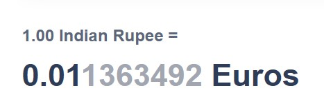

As we are not used to Indian Rupees, it would be more clear to change to Euros :

```r
data$Price = round(data$Price*0.0113,1)
```

```r
#unique(data$Number.of.SIMs)
#Only 3 levels of Numbre.Of.SIMs so it can be recognised as a Factor
data$Number.of.SIMs = as.factor(data$Number.of.SIMs)

data = data %>% dplyr::select(!c(X,Model,Name,Brand,))


#FE of some columns in case it is useful in the future
data = data %>% mutate(both_cameras = Rear.camera + Front.camera)

tot_resolution = paste0(data$Resolution.x,"x",data$Resolution.y)


summary(data)
```

```
##  Battery.capacity..mAh. Screen.size..inches. Touchscreen  Resolution.x
##  Min.   :1010           Min.   :2.400        No :  17    Min.   : 240.0
##  1st Qu.:2300           1st Qu.:5.000        Yes:1342    1st Qu.: 720.0
##  Median :3000           Median :5.200                    Median : 720.0
##  Mean   :2938           Mean   :5.291                    Mean   : 811.5
##  3rd Qu.:3500           3rd Qu.:5.700                    3rd Qu.:1080.0
##  Max.   :6000           Max.   :7.300                    Max.   :2160.0
##   Resolution.y    Processor         RAM..MB.     Internal.storage..GB.
##  Min.   : 320   Min.   : 1.000   Min.   :   64   Min.   :  0.064
##  1st Qu.:1280   1st Qu.: 4.000   1st Qu.: 1000   1st Qu.:  8.000
##  Median :1280   Median : 4.000   Median : 2000   Median : 16.000
##  Mean   :1491   Mean   : 5.551   Mean   : 2489   Mean   : 30.655
##  3rd Qu.:1920   3rd Qu.: 8.000   3rd Qu.: 3000   3rd Qu.: 32.000
##  Max.   :3840   Max.   :10.000   Max.   :12000   Max.   :512.000
##   Rear.camera      Front.camera    Operating.system   Wi.Fi      Bluetooth
##  Min.   :  0.00   Min.   : 0.000   Length:1359        No :   8   No :  15
##  1st Qu.:  8.00   1st Qu.: 2.000   Class :character   Yes:1351   Yes:1344
##  Median : 12.20   Median : 5.000   Mode  :character
##  Mean   : 12.07   Mean   : 7.038
##  3rd Qu.: 13.00   3rd Qu.: 8.000
##  Max.   :108.00   Max.   :48.000
##   GPS       Number.of.SIMs  X3G       X4G..LTE       Price
##  No : 108   1: 227         No : 145   No : 347   Min.   :   5.60
##  Yes:1251   2:1131         Yes:1214   Yes:1012   1st Qu.:  53.85
##             3:   1                               Median :  79.10
##                                                  Mean   : 129.56
##                                                  3rd Qu.: 135.60
##                                                  Max.   :1977.40
##   both_cameras
##  Min.   :  0.00
##  1st Qu.: 10.00
##  Median : 18.00
##  Mean   : 19.11
##  3rd Qu.: 21.00
##  Max.   :148.00
```

```r
#numeric data

data_numeric = data %>% dplyr::select(where(is.numeric))
```

## NAs

```r
library(mice)
md.pattern(data,rotate.names = T)
```

```
##  /\     /\
## {  `---'  }
## {  O   O  }
## ==>  V <==  No need for mice. This data set is completely observed.
##  \  \|/  /
##   `-----'
```

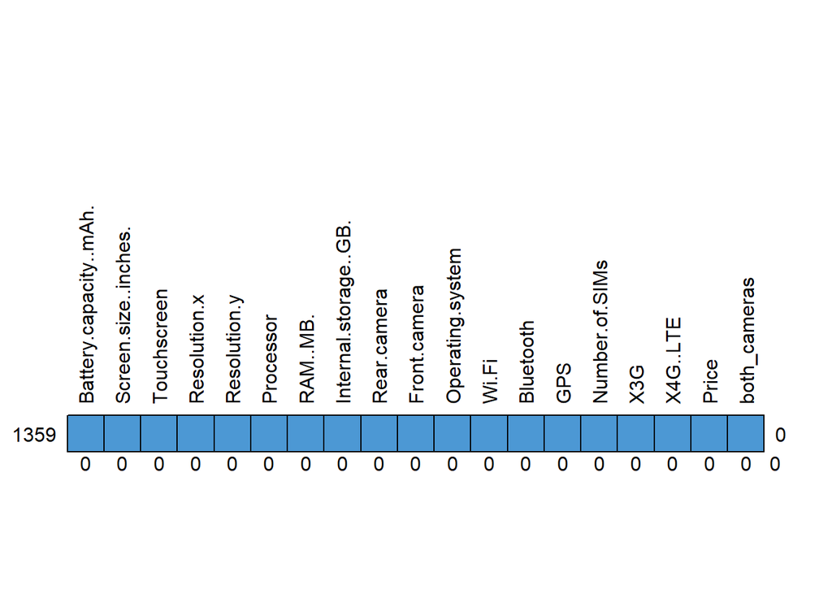

```
##      Battery.capacity..mAh. Screen.size..inches. Touchscreen Resolution.x
## 1359                      1                    1           1            1
##                           0                    0           0            0
##      Resolution.y Processor RAM..MB. Internal.storage..GB. Rear.camera
## 1359            1         1        1                     1           1
##                 0         0        0                     0           0
##      Front.camera Operating.system Wi.Fi Bluetooth GPS Number.of.SIMs X3G
## 1359            1                1     1         1   1              1   1
##                 0                0     0         0   0              0   0
##      X4G..LTE Price both_cameras
## 1359        1     1            1 0
##             0     0            0 0
```

##NAs removal In our case, the dataset do not have NAs in any of its columns as it can be seen in the previous step.

Anyway downwards are described the steps we would have to follow in order to eliminate/predict them.

We could substitute the values by the median of each category: (Imagine Front.Camera had NAs)

```r
#data$Front.camera[is.na(data$Front.camera)]=median(data$Front.camera,na.rm = T)
```

By multiple imputation:

```r
# mult_imp = mice(data, method = "rf")
# obj_mult_imp = complete(mult_imp)
#
# data$Front.camera[is.na(data$Front.camera)] = obj_mult_imp$Front.Camera[is.na(data$Front.camera)]
```

By a Linear Model:

```r
# linear_model = lm(Front.camera ~ log(RAM..MB.) + Operating.system + Rear.camera, data = data[!is.na(data$Front.camera),])
#
# data$Front.camera[is.na(data$Front.camera)] = predict(linear_model, newdata = data[is.na(data$Front.camera),])
```

## Outliers

When NAs are removed, we need to consider outliers, so we create a boxplot to analyse the distribution of each variable.

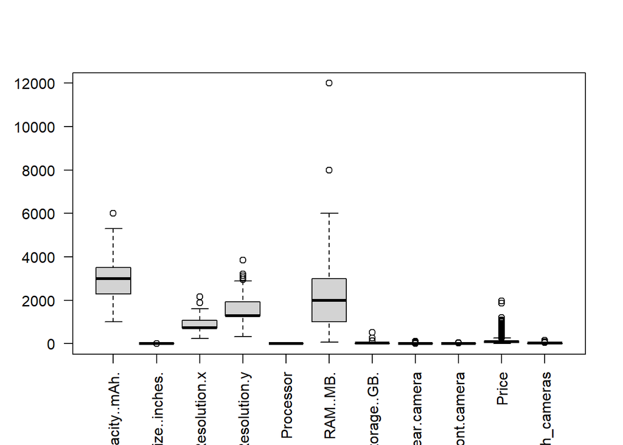

```r
boxplot(data_numeric, las = 2) #Not useful since it has no normalization
```

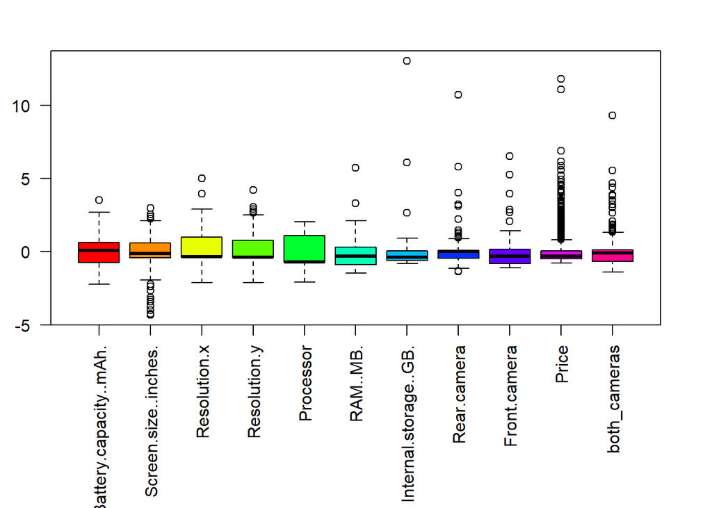

```r
par(mai=c(1.8,0.5,0.5,0.5))
boxplot(scale(data_numeric), las = 2, col = rainbow(11))
```

It is easy to see some outliers in some of the numeric variables of the graph.

Since the features oscillates between the values correctly, I have considered the decission of not removing SOME of the outliers because of the following reasons:

-There are non erroneous data in any of the columns. With the expression erroneus data it is meant that there are no values that do not concord with the nature of each variable. (e.g. There are no negative processors or RAM memory)

In case we had it we would have to remove it

```r
# data = data  %>% filter(variable_needed>0)
```

-Although Price presents lots of outliers it is the target variable of the project and it is logical that some of the prices of some products are big or small.

-With cameras, it is more than the same, extreme values are not removed because there are smartphones that have far more camera resolution than others.

The code if we removed all the outliers will be:

```r
# library(outliers)

#If we want to remove the outliers of every column:
# for (j in 1:ncol(data_numeric){
#   Q_1 = quantile(data_numeric[,i],1/4)
#   Q_3 = quantile(data_numeric[,i],3/4)
#   IQR = Q_3-Q_1
#
#   data = data[data_numeric[,i]>(Q1-1.5*IQR) & data_numeric[,i]<(Q3+1.5*IQR),]
# }

#If we only want to remove it from one column we do the upper process only with the i of the row

# Or with outliers library
# i.e. outliers::outlier(data$Rear.camera)

#numeric selection for analysis
```

## Visualization

The analysis of the variable it is going to be used is:

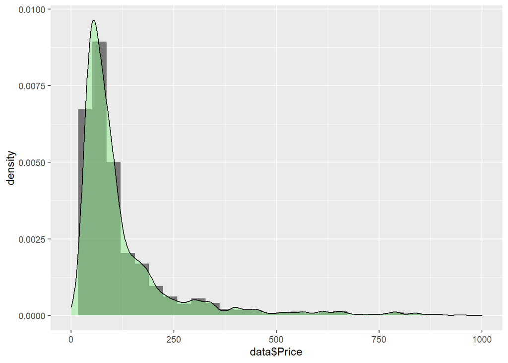

```r
library(ggplot2)
ggplot()+aes(x = data$Price, y = ..density..)+
  geom_histogram(fill = "black",alpha = 0.5)+geom_density(fill = "lightgreen",alpha = 0.5)+xlim(c(0,1000))
```

```r
#3 extreme values remvoed for better visualization.
```

There we can see that most of the mobiles are valued in the interval [0,25.000] Rp

```r
library(tidyverse)
library(caret)
```

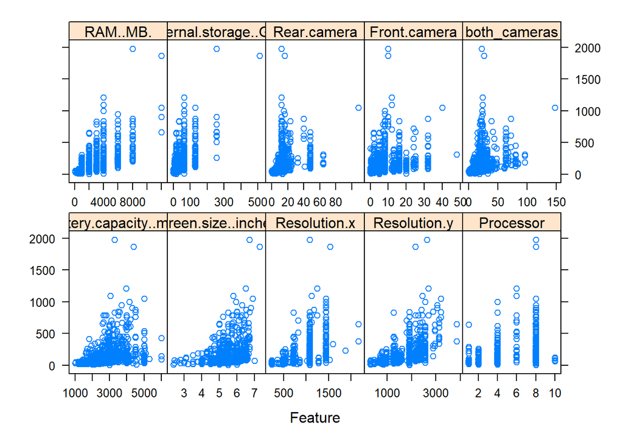

```r
library(e1071)


featurePlot(x = data_numeric[,-10], y = data$Price, layout = c(5,2))
```

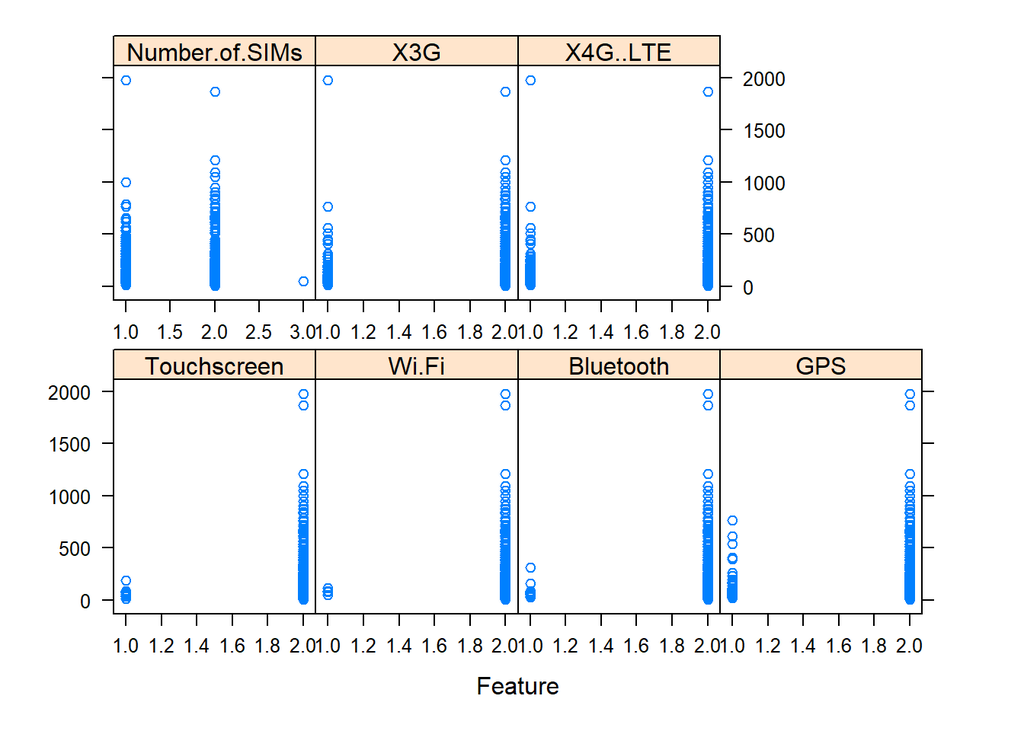

```r
featurePlot(x = lapply(data %>% dplyr::select(where(is.factor)),as.numeric,MARGIN = 2), y = data$Price,
            layout = c(4,2), plot = "scatter")
```

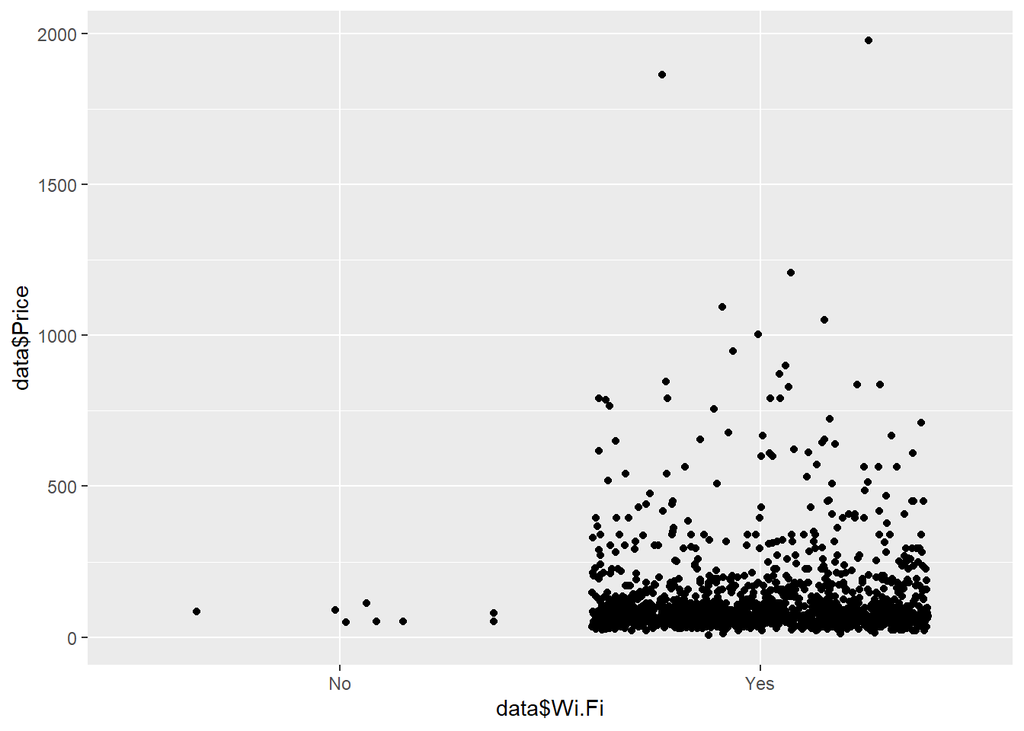

```r
#factors can also be seeen with jitter plots
ggplot()+ aes(x = data$Wi.Fi, y = data$Price) + geom_jitter()
```

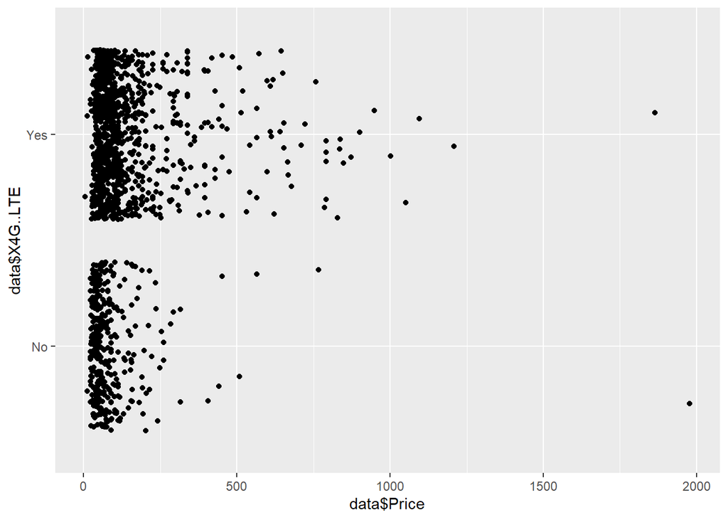

```r
ggplot()+aes(y = data$X4G..LTE , x = data$Price) + geom_jitter()
```

There can be seen some direct proportionality between several features such as Resolution or battery cappacity with the Price variable.

Factors can also be represented in a feature plot but they do not show such important information.

It is easy to appreciate that the mobiles that have 4G or Wi.Fi costs more money than those that do not have it.

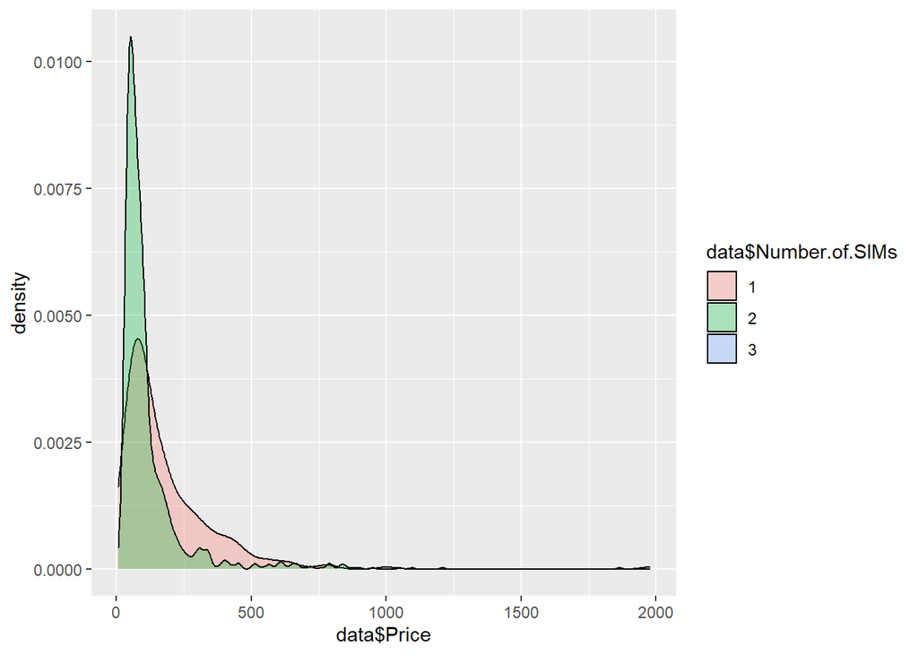

```r
ggplot()+aes(fill = data$Number.of.SIMs, x = data$Price)+geom_density(alpha = 0.3)
```

It is significant to notice the strange evolution of the previous graph since devices with 1 SIM slots are more expensive than the devices with 2 of them. Devices with 3 slots are not even appreciated since there are less than 2 in this database.

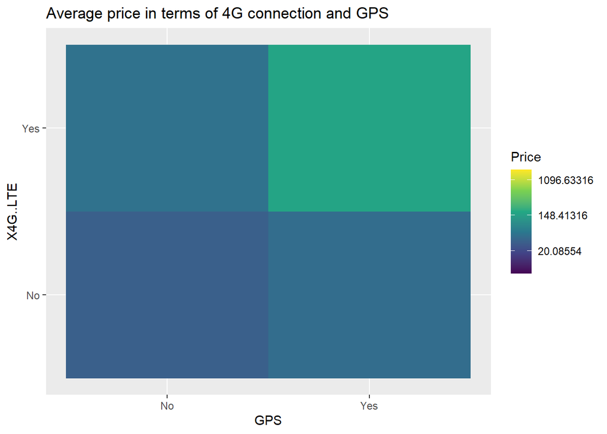

```r
ggplot(data)+aes(x = GPS, y = X4G..LTE)+geom_tile(aes(fill=Price))+
  labs(title = "Average price in terms of 4G connection and GPS")+scale_fill_viridis_c(trans = "log")
```

Easy to see that the more “expensive” mean prices are the ones that have both GPS and 4G

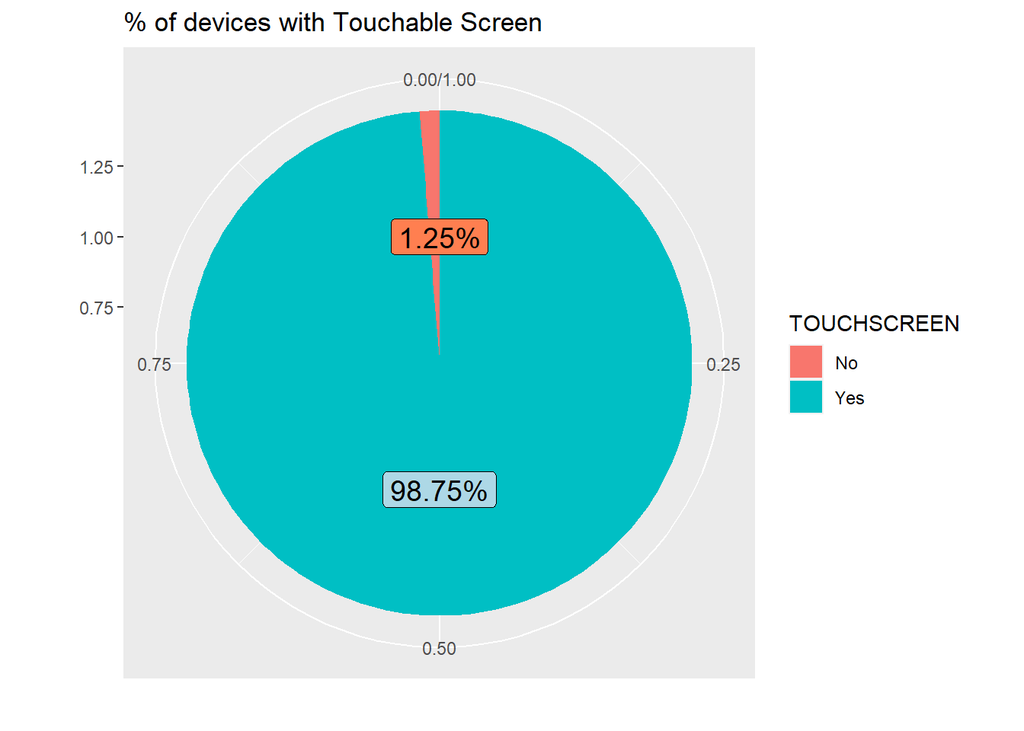

```r
ggplot()+aes(x = 1,fill = data$Touchscreen)+geom_bar(position = position_fill())+coord_polar(theta = "y")+
  scale_fill_discrete(name="TOUCHSCREEN")+
  geom_label(aes(x =1, y =0.5,label= paste0(round(100*sum(data$Touchscreen=="Yes")/sum(nrow(data)),2),"%")),color="black",size=5,fill="lightblue")+
  geom_label(aes(x =1, y =0,label= paste0(round(100*sum(data$Touchscreen=="No")/sum(nrow(data)),2),"%")),color="black",size=5,fill="coral")+
  labs(x= "", y = "", title = "% of devices with Touchable Screen")
```

Really few devices without Touchscreen.

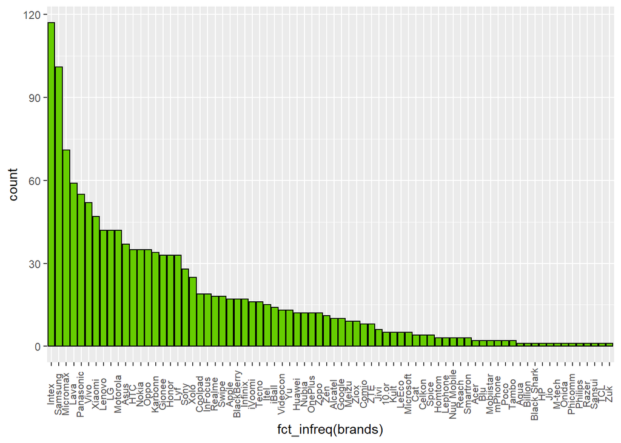

```r
ggplot()+aes(x = fct_infreq(brands))+geom_bar(color = "black", fill = "chartreuse3")+theme(axis.text.x = element_text(angle = 90, vjust = 0.3, size = 8))
```

Devices brands with most appearences are Intex, Samsung and Microm.

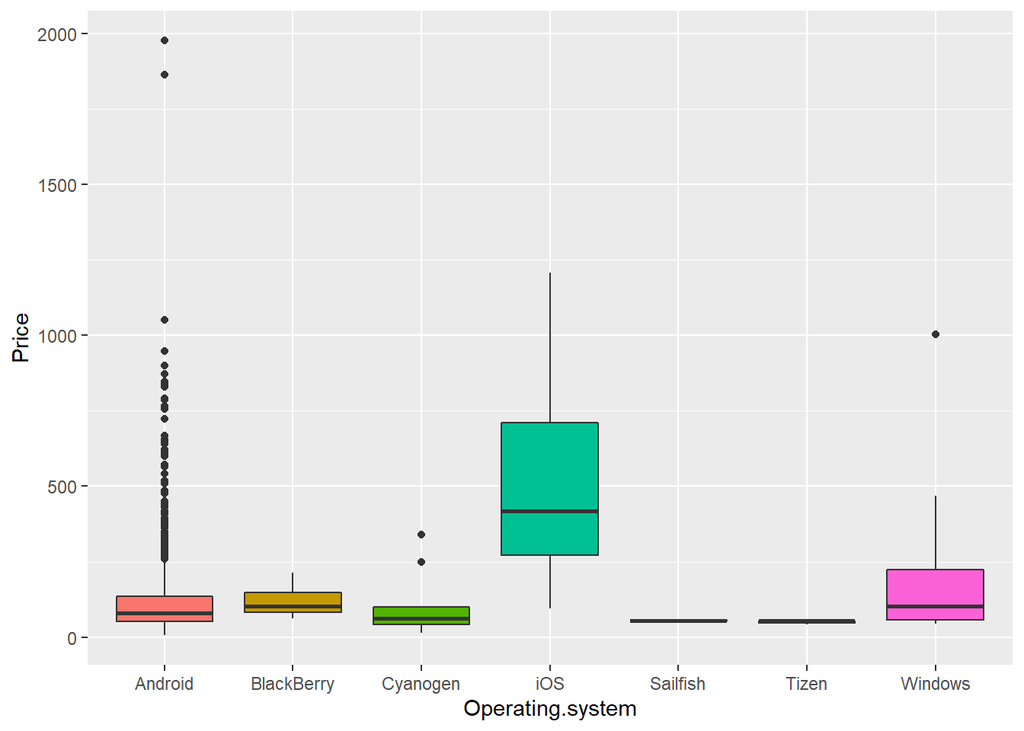

```r
ggplot(data)+aes(x = Operating.system, y = Price, fill = Operating.system)+geom_boxplot()+theme(legend.position = "none")
```

The graph shows how iOS present the most expensive Software. iOS is the company of Apple and it is well known that these devices are used to be the most expensive ones.

Sailfish and Tizen are not really represented since we do not have enough devices of them (1 and 3 respectively).

It is better to remove them for the modeling part

```r
table(data$Operating.system)
```

```
##
##    Android BlackBerry   Cyanogen        iOS   Sailfish      Tizen    Windows
##       1299         10         10         17          1          3         19
```

```r
#removing few appearances since it does not help in anything:
brands = brands[!(data$Operating.system=="Sailfish"|data$Operating.system=="Tizen"|data$Number.of.SIMs==3)]
names = names[!(data$Operating.system=="Sailfish"|data$Operating.system=="Tizen"|data$Number.of.SIMs==3)]
tot_resolution = tot_resolution[!(data$Operating.system=="Sailfish"|data$Operating.system=="Tizen"|data$Number.of.SIMs==3)]
data_numeric = data_numeric[!(data$Operating.system=="Sailfish"|data$Operating.system=="Tizen"|data$Number.of.SIMs==3),]
data = data[!(data$Operating.system=="Sailfish"|data$Operating.system=="Tizen"|data$Number.of.SIMs==3),]
data$Number.of.SIMs = factor(data$Number.of.SIMs)
data$Operating.system = factor(data$Operating.system)
```

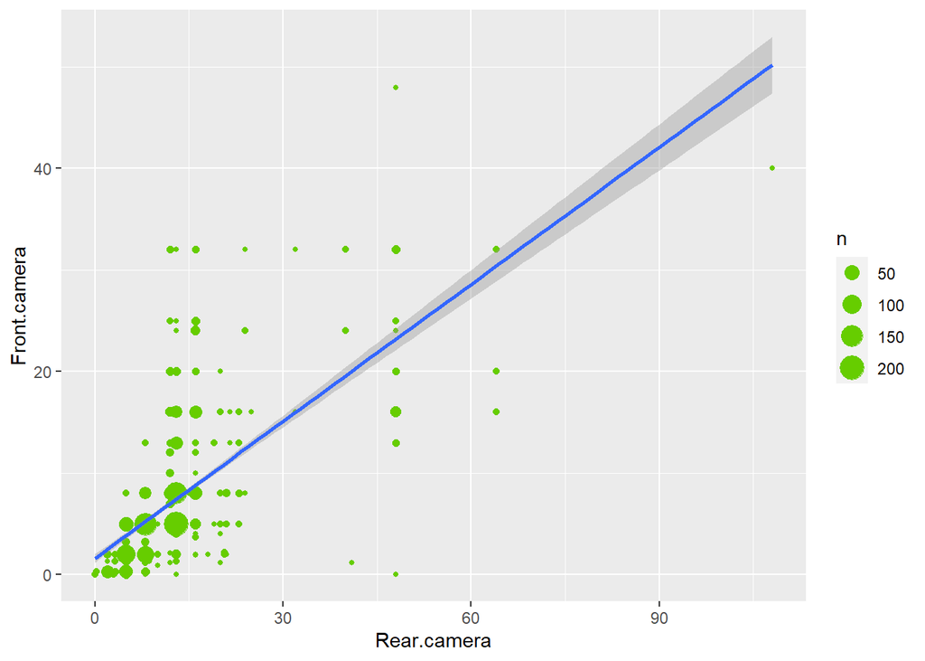

```r
ggplot(data)+aes(x = Rear.camera, y = Front.camera)+ geom_count(color  ="chartreuse3")+geom_smooth(method = "lm")
```

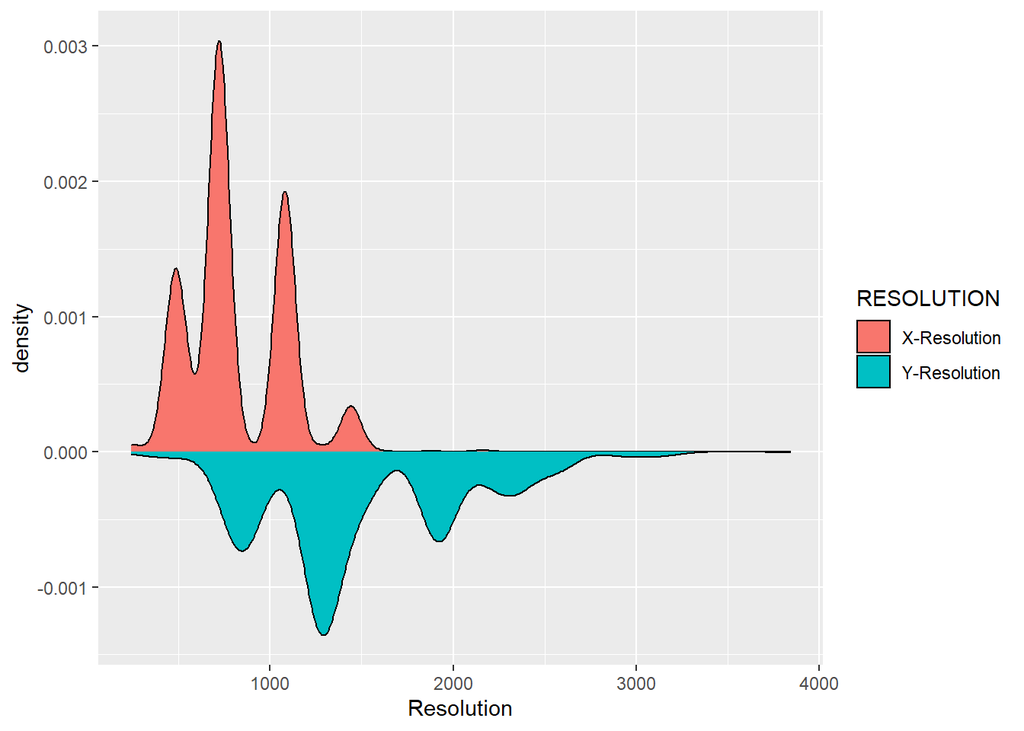

```r
ggplot()+geom_density(aes(x=data$Resolution.x, y = ..density.., fill = "X-Resolution"))+
  geom_density(aes(x=data$Resolution.y, y =-..density..,fill = "Y-Resolution"))+labs(x="Resolution")+
  scale_fill_discrete(name = "RESOLUTION")
```

As devices are usually longer than wider it is normal that the most frequent values of X resolution are lower than Y resolution. The most frequent X value is located near 800 and Y value near 1300.

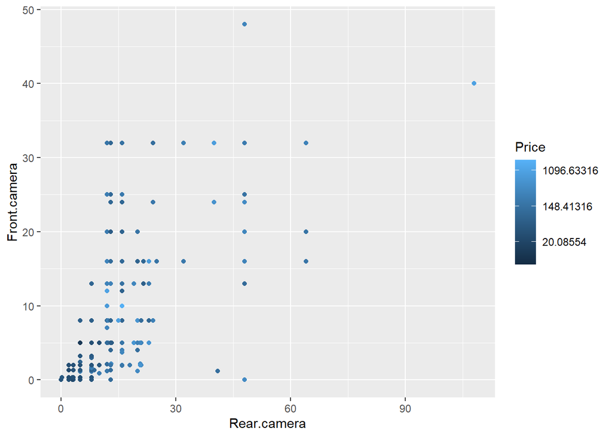

```r
ggplot(data)+aes(x=Rear.camera, y = Front.camera)+geom_point(aes(color = Price))+scale_color_continuous(trans = "log")
```

There can be appreciated the direct relation between the back and Front camera.

Furthermore, it is well graphed that with the increase on the MP of the cameras, the mobile prices increases

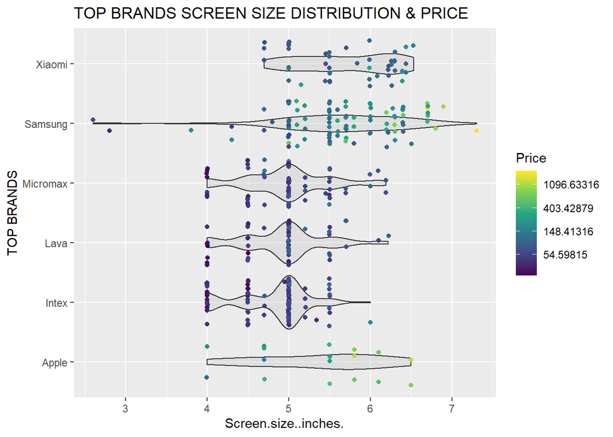

```r
ggplot(data %>% filter(brands %in% c("Intex","Samsung","Apple","Micromax","Xiaomi","Lava")))+aes(x=Screen.size..inches.,
                                                                                                 y=brands[brands %in% c("Intex","Samsung","Apple","Micromax","Xiaomi","Lava")])+
  geom_violin(alpha = 0.3, fill = "grey")+
  geom_jitter(aes(color = Price))+scale_color_viridis_c(trans = "log")+
  labs(title = "TOP BRANDS SCREEN SIZE DISTRIBUTION & PRICE", y = "TOP BRANDS")
```

It was selected with the filter the most known brands of the dataset and the comparison with their size show how the Apple, Samsung and Xiaomi phones are related with the bigger screen diagonal.

Moreover, price was plotted as jitter dots and it is shown in brighter colors the most expensive ones surrounding the Apple and Samsung boxplots, that are globally known as the most expensive brands.

```r
set.seed(1)
splits_1 = createDataPartition(data$Price, p = 4/5, list = FALSE)
train_data = data[splits_1,]
test_data = data[-splits_1,]
```

# CLASSIFICATION

For the classification of the variable that is wanted to be predicted, it is needed to cut into factors.

The decission is to divide in 2 different groups:

- EXPENSIVE -> Mobiles that cost more than 120€
- CHEAP -> Mobiles that cost less or equal than 120€

(As a remainder, we have to assume these dataset is extracted from INDIA, where the economical situation is not as good as in Europe. It is assumed then that their budget when buying an smartphone is lower)

But first, let’s make a first analysis of the correlation of the numeric values within the variable we want to analyse(ALTHOUGH THIS PART IS LOCATED IN THE CLASSIFICATION PART, IT IS ONLY THE FIRST APPROACH AS AN INTRODUCTION, SO IT WILL BE REPEATED IN THE REGRESSION PART):

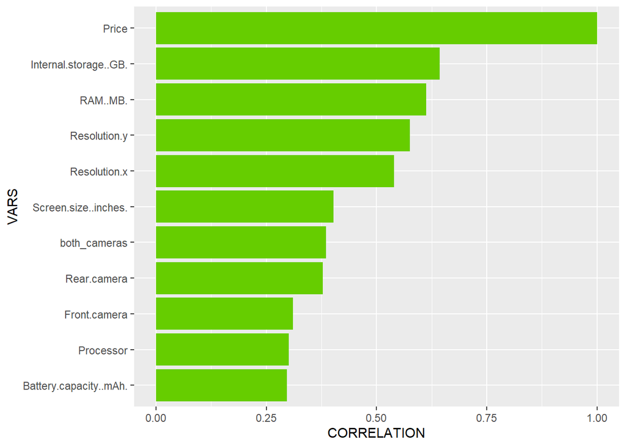

```r
ggplot()+aes(x=cor(data_numeric)["Price",], y = reorder(names(cor(data_numeric)["Price",]),
                                                         cor(data_numeric)["Price",])) +
  geom_col(fill = "chartreuse3")+labs(x="CORRELATION",y="VARS")
```

The variables that presents most correlation within the price are Storage, RAM and Screen Resolution that indeed are one of the most important features in smartphones evaluation.

The correlation within the variables are:

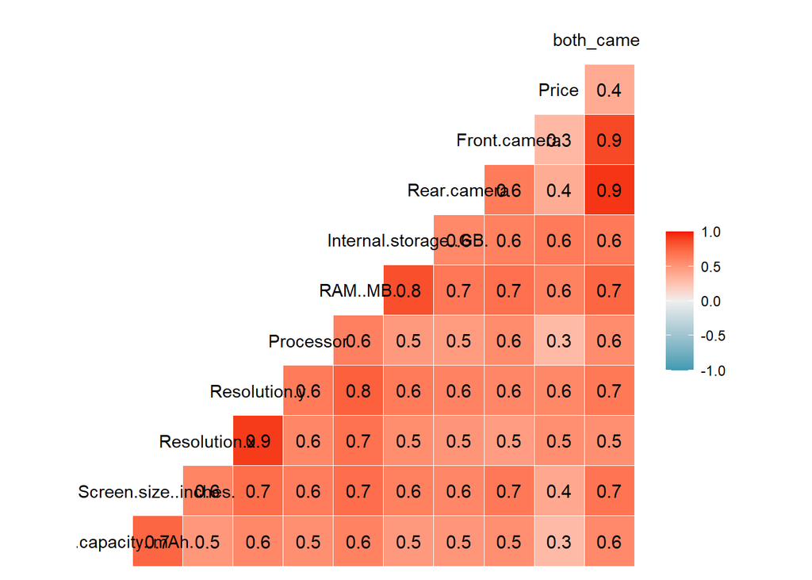

```r
library(GGally)
ggcorr(data, label = T)
```

There are some extreme correlations that have sense such as Resolution in both axis and the correlation between both_cameras with each of the cameras.

As a first approach to our dataset and before separating in factors, it can be analysed a multiple regression with for example 3 variables.

```r
st_approach = lm(Price ~ Internal.storage..GB. + X3G + both_cameras, data = train_data)
summary(st_approach)
```

```
##
## Call:
## lm(formula = Price ~ Internal.storage..GB. + X3G + both_cameras,
##     data = train_data)
##
## Residuals:
##     Min      1Q  Median      3Q     Max
## -488.69  -41.83  -21.59    5.78 1195.85
##
## Coefficients:
##                       Estimate Std. Error t value Pr(>|t|)
## (Intercept)            31.9664    12.1335   2.635  0.00855 **
## Internal.storage..GB.   2.9932     0.1221  24.519  < 2e-16 ***
## X3GYes                 22.7661    11.4872   1.982  0.04775 *
## both_cameras           -0.7585     0.3307  -2.294  0.02200 *
## ---
## Signif. codes:  0 '***' 0.001 '**' 0.01 '*' 0.05 '.' 0.1 ' ' 1
##
## Residual standard error: 117.3 on 1081 degrees of freedom
## Multiple R-squared:  0.4517, Adjusted R-squared:  0.4502
## F-statistic: 296.8 on 3 and 1081 DF,  p-value: < 2.2e-16
```

The $R^2$ obtained is not that bad since the model was created with random variables chosen. The $R^2$ obtained between the predicted values and the actual values will be:

```r
cor(predict(st_approach, newdata=test_data),test_data$Price)^2
```

```
## [1] 0.2764963
```

```r
orig_price = data$Price

data$Price[data$Price>120]="EXPENSIVE"
data$Price[data$Price!="EXPENSIVE"]="CHEAP"
data$Price = as.factor(data$Price)
levels(data$Price)
```

```
## [1] "CHEAP"     "EXPENSIVE"
```

```r
table(data$Price)
```

```
##
##     CHEAP EXPENSIVE
##       963       391
```

In the table it can be seen that there are much more Cheap devices than Expensive ones.

The data is not really well-balanced.

### Few Visualization for price in factors

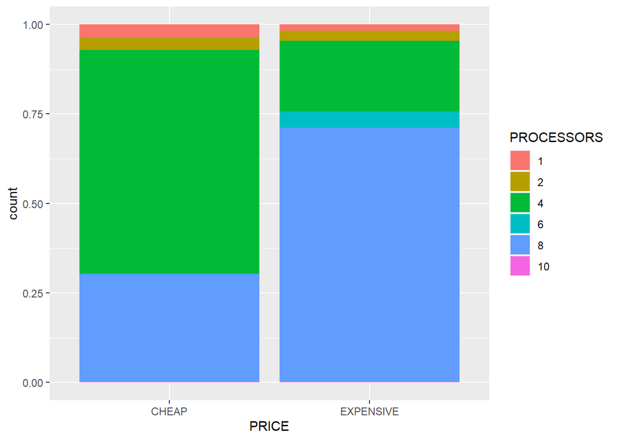

```r
ggplot(data)+aes(x = Price)+geom_bar(aes(fill = as.factor(Processor)), position = position_fill())+labs(x = "PRICE")+scale_fill_discrete(name = "PROCESSORS")
```

We can see that expensive mobiles ussually have more processors than cheap ones.

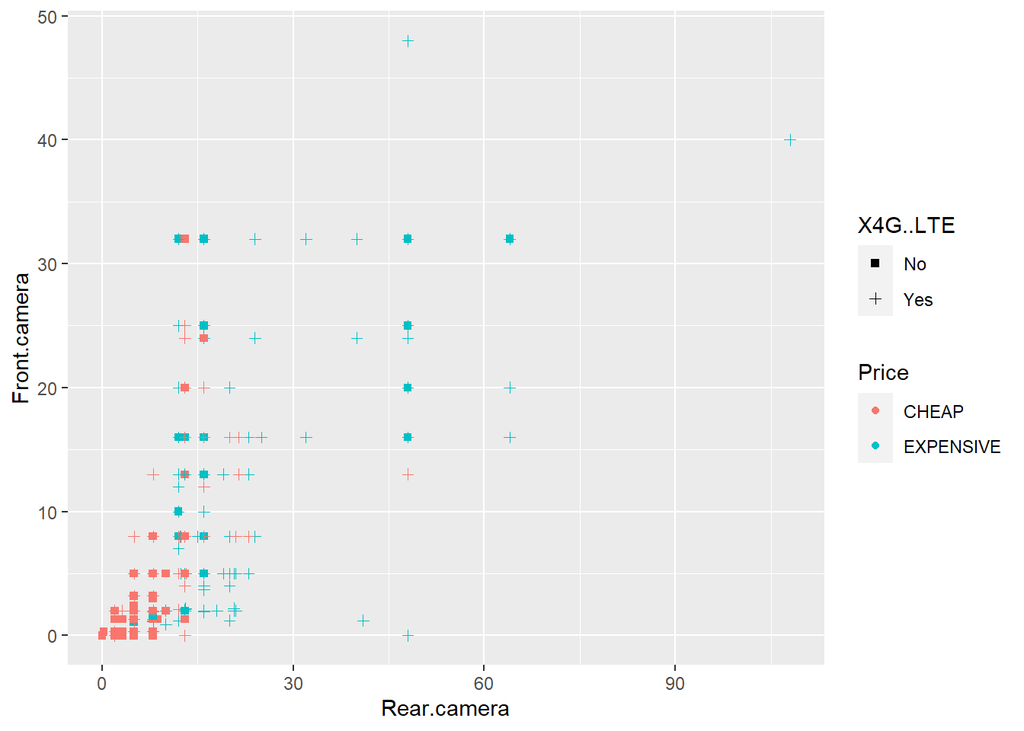

```r
ggplot(data)+aes(x = Rear.camera, y = Front.camera)+geom_point(aes(color = Price,shape = X4G..LTE))+scale_shape_manual(values = c(15,3))
```

Slightly more expensive smartphones have 4G since we can see less red crosses.

Splitting:

```r
splits_2 = createDataPartition(data$Price, p = 4/5, list = FALSE)
train_data2 = data[splits_2,]
test_data2 = data[-splits_2,]
```

As a Benchmark model used for the 1st approach

```r
max(table(test_data2$Price))/nrow(test_data2)
```

```
## [1] 0.7111111
```

This benchmark model is kind of the lower accuracy that can be reached in our models.

Since it represents the most frequent outcome in prediction.

This model will clasify as CHEAP with a 71% of probability

## BAYES CLASSIFICATION

### LDA

At first, it is performed a Linear Discriminant Analysis(LDA) is performed.

```r
library(MASS)
lda_1 = lda(Price ~., data = train_data2, prior = c(0.8,0.2))
lda_1
```

```
## Call:
## lda(Price ~ ., data = train_data2, prior = c(0.8, 0.2))
##
## Prior probabilities of groups:
##     CHEAP EXPENSIVE
##       0.8       0.2
##
## Group means:
##           Battery.capacity..mAh. Screen.size..inches. TouchscreenYes
## CHEAP                   2776.582             5.129040      0.9883268
## EXPENSIVE               3377.930             5.719617      1.0000000
##           Resolution.x Resolution.y Processor RAM..MB. Internal.storage..GB.
## CHEAP         714.9053     1282.211  5.038911 1892.027              18.26514
## EXPENSIVE    1058.2077     2020.562  6.926518 3996.805              61.99361
##           Rear.camera Front.camera Operating.systemBlackBerry
## CHEAP        9.518418     5.316602                0.005188067
## EXPENSIVE   18.706070    11.220767                0.012779553
##           Operating.systemCyanogen Operating.systemiOS Operating.systemWindows
## CHEAP                  0.007782101          0.00000000              0.01167315
## EXPENSIVE              0.003194888          0.03833866              0.02236422
##            Wi.FiYes BluetoothYes    GPSYes Number.of.SIMs2    X3GYes
## CHEAP     0.9909209    0.9857328 0.9040208       0.8780804 0.8910506
## EXPENSIVE 1.0000000    0.9968051 0.9616613       0.7028754 0.8945687
##           X4G..LTEYes both_cameras
## CHEAP       0.6913100     14.83502
## EXPENSIVE   0.8498403     29.92684
##
## Coefficients of linear discriminants:
##                                      LD1
## Battery.capacity..mAh.     -8.306212e-05
## Screen.size..inches.       -3.842406e-01
## TouchscreenYes              1.857540e-01
## Resolution.x                1.537626e-03
## Resolution.y                6.941728e-04
## Processor                   1.622108e-02
## RAM..MB.                    1.825952e-04
## Internal.storage..GB.       8.485011e-03
## Rear.camera                 1.154623e-02
## Front.camera                1.897288e-02
## Operating.systemBlackBerry  8.125254e-01
## Operating.systemCyanogen    5.379934e-01
## Operating.systemiOS         2.327476e+00
## Operating.systemWindows     4.810425e-01
## Wi.FiYes                    2.732068e-01
## BluetoothYes                3.370100e-01
## GPSYes                      4.267766e-01
## Number.of.SIMs2            -5.560954e-01
## X3GYes                      4.356720e-01
## X4G..LTEYes                -3.725060e-01
## both_cameras                9.119244e-03
```

Note we only have 2 groups so there is only LD1 coefficient obtained.

So LD1 has the whole proportion of trace 1.

Notice that iOS operating System is the feature that contributes the most to LD1 since it is carried in the most expensive smartphones

```r
res_lda_1 = predict(lda_1, newdata = test_data2)
head(res_lda_1$posterior)
```

```
##          CHEAP EXPENSIVE
## 6  0.030589040 0.9694110
## 11 0.260589742 0.7394103
## 14 0.003537936 0.9964621
## 15 0.031927191 0.9680728
## 16 0.284777477 0.7152225
## 24 0.004566273 0.9954337
```

```r
prob_lda = res_lda_1$posterior
```

The classification probabilities are in general really high so that means that the model is expected to work well.

```r
conf_lda1 = confusionMatrix(res_lda_1$class, test_data2$Price)
conf_lda1
```

```
## Confusion Matrix and Statistics
##
##            Reference
## Prediction  CHEAP EXPENSIVE
##   CHEAP       184        30
##   EXPENSIVE     8        48
##
##                Accuracy : 0.8593
##                  95% CI : (0.812, 0.8984)
##     No Information Rate : 0.7111
##     P-Value [Acc > NIR] : 7.258e-09
##
##                   Kappa : 0.6261
##
##  Mcnemar's Test P-Value : 0.0006577
##
##             Sensitivity : 0.9583
##             Specificity : 0.6154
##          Pos Pred Value : 0.8598
##          Neg Pred Value : 0.8571
##              Prevalence : 0.7111
##          Detection Rate : 0.6815
##    Detection Prevalence : 0.7926
##       Balanced Accuracy : 0.7869
##
##        'Positive' Class : CHEAP
##
```

So the accuracy obtained is really good for the model. Reaching near 0.85. But LDA is not the best model for classification in 2 groups.

If we did not include prior, the class proportions for the training set will be used so:

```r
lda_wo_prior = lda(Price ~., data = train_data2)
conf_lda_2 = confusionMatrix(predict(lda_wo_prior,newdata=test_data2)$class,test_data2$Price)
conf_lda_2
```

```
## Confusion Matrix and Statistics
##
##            Reference
## Prediction  CHEAP EXPENSIVE
##   CHEAP       181        29
##   EXPENSIVE    11        49
##
##                Accuracy : 0.8519
##                  95% CI : (0.8038, 0.892)
##     No Information Rate : 0.7111
##     P-Value [Acc > NIR] : 4.284e-08
##
##                   Kappa : 0.6129
##
##  Mcnemar's Test P-Value : 0.00719
##
##             Sensitivity : 0.9427
##             Specificity : 0.6282
##          Pos Pred Value : 0.8619
##          Neg Pred Value : 0.8167
##              Prevalence : 0.7111
##          Detection Rate : 0.6704
##    Detection Prevalence : 0.7778
##       Balanced Accuracy : 0.7855
##
##        'Positive' Class : CHEAP
##
```

### QDA

Trying with QDA could give a different approach since they are kind of the same method but in the Quadratic Discriminant Analysis it is asumed that the covariances matrices can be different in each of the classes(EXPENSIVE vs CHEAP), so it will be estimated separately.

```r
#qda_1 = qda(Price ~., data = train_data2) #prior I would use , prior = c(0.8,0.2)
#qda_1
```

When trying QDA there is a rank deficiency problem in group CHEAP. This could means that there is insufficient information contained in the data to estimate the model

The code to achieve the confusiosionMatrix of QDA would follow the same pattern.

## Logistic Regression

Another way to achieve Classification will be the Logistic Regression, that is said to be one of the best model for binary(2 classes) classification. It is also said to be the derivation of a multiple regression model to predict numerical values, but in this case, on discrete ones:

```r
set.seed(1)
library(glmnet)
log_reg = glm(Price~., data = train_data2, family = binomial)
summary(log_reg)
```

```
##
## Call:
## glm(formula = Price ~ ., family = binomial, data = train_data2)
##
## Deviance Residuals:
##     Min       1Q   Median       3Q      Max
## -2.5462  -0.4562  -0.2582   0.1090   2.6593
##
## Coefficients: (1 not defined because of singularities)
##                              Estimate Std. Error z value Pr(>|z|)
## (Intercept)                -3.519e+01  1.790e+03  -0.020 0.984310
## Battery.capacity..mAh.     -6.348e-05  1.704e-04  -0.373 0.709481
## Screen.size..inches.       -4.759e-01  3.056e-01  -1.557 0.119386
## TouchscreenYes              1.441e+01  1.243e+03   0.012 0.990753
## Resolution.x                2.857e-03  9.225e-04   3.097 0.001954 **
## Resolution.y                3.489e-04  5.217e-04   0.669 0.503613
## Processor                   2.012e-02  6.280e-02   0.320 0.748683
## RAM..MB.                    4.370e-04  1.665e-04   2.625 0.008664 **
## Internal.storage..GB.       2.654e-02  7.744e-03   3.427 0.000610 ***
## Rear.camera                 7.367e-02  2.457e-02   2.999 0.002710 **
## Front.camera                8.748e-03  2.496e-02   0.351 0.725959
## Operating.systemBlackBerry  1.189e+00  8.836e-01   1.346 0.178395
## Operating.systemCyanogen    7.071e-01  1.411e+00   0.501 0.616312
## Operating.systemiOS         1.795e+01  1.045e+03   0.017 0.986296
## Operating.systemWindows     8.322e-01  7.535e-01   1.104 0.269441
## Wi.FiYes                    1.473e+01  1.287e+03   0.011 0.990870
## BluetoothYes                7.926e-01  1.228e+00   0.645 0.518622
## GPSYes                      1.268e+00  5.008e-01   2.532 0.011356 *
## Number.of.SIMs2            -9.607e-01  2.753e-01  -3.489 0.000485 ***
## X3GYes                      1.292e+00  4.314e-01   2.996 0.002735 **
## X4G..LTEYes                -1.043e+00  3.322e-01  -3.141 0.001686 **
## both_cameras                       NA         NA      NA       NA
## ---
## Signif. codes:  0 '***' 0.001 '**' 0.01 '*' 0.05 '.' 0.1 ' ' 1
##
## (Dispersion parameter for binomial family taken to be 1)
##
##     Null deviance: 1303.02  on 1083  degrees of freedom
## Residual deviance:  690.08  on 1063  degrees of freedom
## AIC: 732.08
##
## Number of Fisher Scoring iterations: 16
```

Note: Errors are not taken into acount in this equation.

```r
prob_log_reg = predict(log_reg, type = "response", newdata = test_data2)
prob_log_reg[1:10]
```

```
##         6        11        14        15        16        24        27        28
## 0.9951371 0.8407711 0.9990180 0.9965069 0.7203312 1.0000000 0.9825714 0.9862838
##        30        36
## 0.3349636 0.9372462
```

Most of this first data are classified as EXPENSIVE since the p is higher than 0.5.

But indeed, this 0.5 setting is only a parameter placed by the user so it can be optimized in the following methods.

```r
prob_log_reg[prob_log_reg > 0.5] = levels(train_data2$Price)[2]
prob_log_reg[prob_log_reg != levels(train_data2$Price)[2]] = levels(train_data2$Price)[1]
prob_log_reg = as.factor(prob_log_reg)
prob_log_reg[1:10]
```

```
##         6        11        14        15        16        24        27        28
## EXPENSIVE EXPENSIVE EXPENSIVE EXPENSIVE EXPENSIVE EXPENSIVE EXPENSIVE EXPENSIVE
##        30        36
##     CHEAP EXPENSIVE
## Levels: CHEAP EXPENSIVE
```

The confusion matrix will finally show the accuracy within the whole test_data.

```r
conf_log_reg = confusionMatrix(prob_log_reg,test_data2$Price)
conf_log_reg
```

```
## Confusion Matrix and Statistics
##
##            Reference
## Prediction  CHEAP EXPENSIVE
##   CHEAP       182        28
##   EXPENSIVE    10        50
##
##                Accuracy : 0.8593
##                  95% CI : (0.812, 0.8984)
##     No Information Rate : 0.7111
##     P-Value [Acc > NIR] : 7.258e-09
##
##                   Kappa : 0.6323
##
##  Mcnemar's Test P-Value : 0.00582
##
##             Sensitivity : 0.9479
##             Specificity : 0.6410
##          Pos Pred Value : 0.8667
##          Neg Pred Value : 0.8333
##              Prevalence : 0.7111
##          Detection Rate : 0.6741
##    Detection Prevalence : 0.7778
##       Balanced Accuracy : 0.7945
##
##        'Positive' Class : CHEAP
##
```

The accuracy achieved is not that better in comparison to the LDA method, although this method is known to perform at its best with binary classification.

This method also presents a derivation that is good to apply when datasets are large enough. It is named:

### PENALIZED LOGISTIC REGRESSION.

The name explains all his performance it tries to find a smaller set of variables of the model for suiting the most favorable model.

In this case, we have learned **ridge classification** Log. Regression(since alpha = 0) that consist mainly in the minimization of the complexity in the model by squaring coefficients so the smaller ones are even closer to zero and so they do not “disturb” the modeling.

In this dataset case, I personally think that this dataset does not fit correctly in this model since it is not large enough but it is going to be tried anyway.

As a first approach alpha=0 -> ridge regression and lambda =0.005 is settled

```r
#use of numeric data for this process:
data_numeric = data_numeric %>% mutate(Price = factor(ifelse(Price>120,"EXPENSIVE","CHEAP")))
splits_3 = createDataPartition(data_numeric$Price, p = 4/5, list = FALSE)
train_data3 = data_numeric[splits_3,]
test_data3 = data_numeric[-splits_3,]

data_numeric = data_numeric %>% mutate(Price = orig_price)

p_log_reg = glmnet(as.matrix(train_data3 %>% dplyr::select(-Price)),train_data3$Price, family = c("binomial"), alpha = 0, lambda = 0.005)
summary(p_log_reg)
```

```
##            Length Class     Mode
## a0          1     -none-    numeric
## beta       10     dgCMatrix S4
## df          1     -none-    numeric
## dim         2     -none-    numeric
## lambda      1     -none-    numeric
## dev.ratio   1     -none-    numeric
## nulldev     1     -none-    numeric
## npasses     1     -none-    numeric
## jerr        1     -none-    numeric
## offset      1     -none-    logical
## classnames  2     -none-    character
## call        6     -none-    call
## nobs        1     -none-    numeric
```

```r
prob_p_log_reg = predict(p_log_reg, as.matrix(test_data3 %>% dplyr::select(-Price)), type = "response")

prob_p_log_reg[prob_p_log_reg > 0.5] = levels(train_data3$Price)[2]
prob_p_log_reg[prob_p_log_reg != levels(train_data2$Price)[2]] = levels(train_data3$Price)[1]
prob_p_log_reg = as.factor(prob_p_log_reg)

conf_p_log_reg = confusionMatrix(prob_p_log_reg, test_data3$Price)
conf_p_log_reg
```

```
## Confusion Matrix and Statistics
##
##            Reference
## Prediction  CHEAP EXPENSIVE
##   CHEAP       182        27
##   EXPENSIVE    10        51
##
##                Accuracy : 0.863
##                  95% CI : (0.8161, 0.9016)
##     No Information Rate : 0.7111
##     P-Value [Acc > NIR] : 2.858e-09
##
##                   Kappa : 0.6434
##
##  Mcnemar's Test P-Value : 0.008529
##
##             Sensitivity : 0.9479
##             Specificity : 0.6538
##          Pos Pred Value : 0.8708
##          Neg Pred Value : 0.8361
##              Prevalence : 0.7111
##          Detection Rate : 0.6741
##    Detection Prevalence : 0.7741
##       Balanced Accuracy : 0.8009
##
##        'Positive' Class : CHEAP
##
```

Results obtained are really similar to the non penalized algorithm.

Accuracy and Kappa did not really change significantly so we could confirm that both models work similarly in this data-set.

## ROC curves

Before continuing,lets do some roc curves to see how the sensitivitys and specificitys develop with different thresholds.

```r
library(pROC)
#first we have to obtain the result in form of probabilities.
roc.lda = roc(test_data2$Price,prob_lda[,2])
```

```r
#The area under the curve is better the bigger it is, since that means that the specificity and precisions are high.
auc(roc.lda)
```

```
## Area under the curve: 0.9011
```

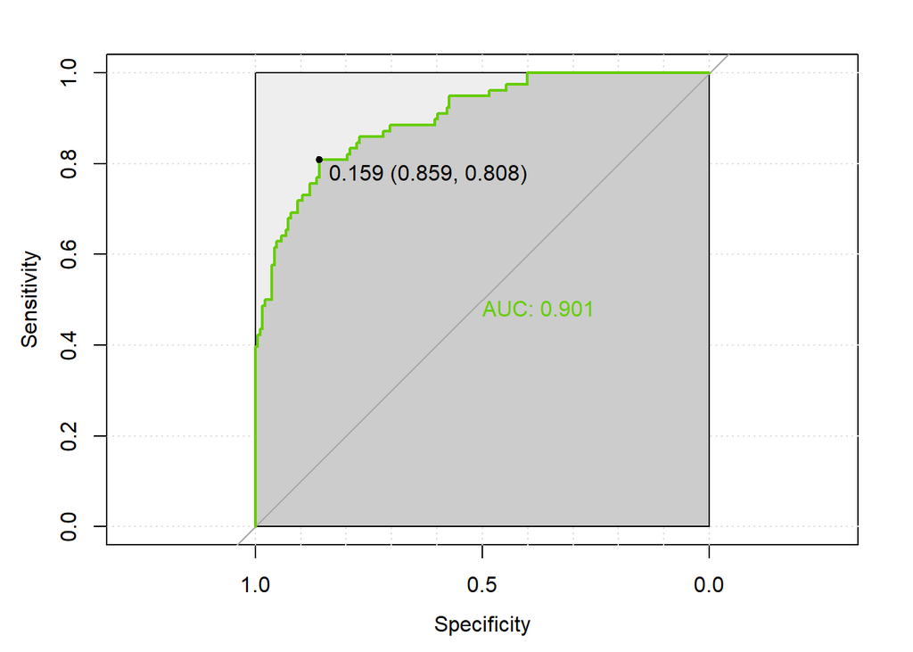

```r
plot.roc(test_data2$Price,prob_lda[,2],col="chartreuse3", print.auc = TRUE,  auc.polygon=TRUE, grid=c(0.1, 0.2), max.auc.polygon=TRUE,auc.polygon.col="grey80", print.thres=TRUE)
```

High area under the curve.

## NAIVE CLASSIFIER

As we are a company, we would like to sell our mobiles extracting the most benefit out of them.

So we can use the NAIVE CLASSIFIER to try for trying to maximize the company earnings.

Our company is supposed to analyse mobile specifications from each manufacturer, buy their mobile phones and we sell them by the price we predict they are valued in our web page.

We will have 4 cases:

- We predict that the mobile is Cheap, and we bought it Cheap: 10 benefit.
- We predict that the mobile is Cheap, and we bought it Expensive: -100 benefit.
- We predict that the mobile is Expensive, and we bought it Cheap: 150 benefit.
- We predict that the mobile is Expensive, and we bought it Expensive: 20 benefit

So :

[output not shown]

In our case, the Naive classifier will look:

$$BENEFITS = 10*0.72+20*0.28-100*0+150*0 =
12.8€$$

This NAIVE CLASSIFIER BENEFIT has to be maximized with the algorithms used all over the classification until now.

So the benefits we want to obtained are contained in the vector:

```r
benef.smartphone = c(20,150,-100,10)
```

Benefits with ALGORITHMS TRIED UNTIL NOW:

```r
paste0("BENEFITS FOR LDA MODEL ARE: ",sum(as.vector(conf_lda1$table)*benef.smartphone)/sum(conf_lda1$table))
```

```
## [1] "BENEFITS FOR LDA MODEL ARE: 8.74074074074074"
```

```r
paste0("BENEFITS FOR LDA MODEL W/O PRIOR ARE: ",sum(as.vector(conf_lda_2$table)*benef.smartphone)/sum(conf_lda_2$table))
```

```
## [1] "BENEFITS FOR LDA MODEL W/O PRIOR ARE: 10.5925925925926"
```

```r
paste0("BENEFITS FOR LOG.REG MODEL ARE: ",sum(as.vector(conf_log_reg$table)*benef.smartphone)/sum(conf_log_reg$table))
```

```
## [1] "BENEFITS FOR LOG.REG MODEL ARE: 10.5185185185185"
```

```r
paste0("BENEFITS FOR PENALIZED LOG.REG ARE: ",sum(as.vector(conf_p_log_reg$table)*benef.smartphone)/sum(conf_p_log_reg$table))
```

```
## [1] "BENEFITS FOR PENALIZED LOG.REG ARE: 10.9259259259259"
```

But this is only with a fixed threshold, so if this threshold is optimized we can obtain then the best LDA model for our prediction:

```r
profits.lda = matrix(NA, 50, 10)

j=0
suppressWarnings(
  for (threshold in seq(0.05,0.5,0.05)){

  j=j+1

  #30 iterations for each threshold setted
  for(i in 1:50){

    sp = createDataPartition(train_data3$Price, p = 0.5, list = FALSE)

    train_data_op = train_data3[sp,]
    test_data_op = train_data3[-sp,]


    lda_optim = lda(Price ~ ., data = train_data_op) #, prior = c(0.8,0.2)

    prob = predict(lda_optim,test_data_op)$posterior

    lda_pred_optim = rep("CHEAP", nrow(test_data_op))
    lda_pred_optim[which(prob[,2] > threshold)] = "EXPENSIVE"

    conf_matrix_optim = confusionMatrix(as.factor(lda_pred_optim), test_data_op$Price)$table

    profits.lda[i,j] = sum(benef.smartphone*as.vector(conf_matrix_optim))/sum(conf_matrix_optim)
  }
})
```

This is interpreted as independent data partitions since we are having into account 50 different data partitions

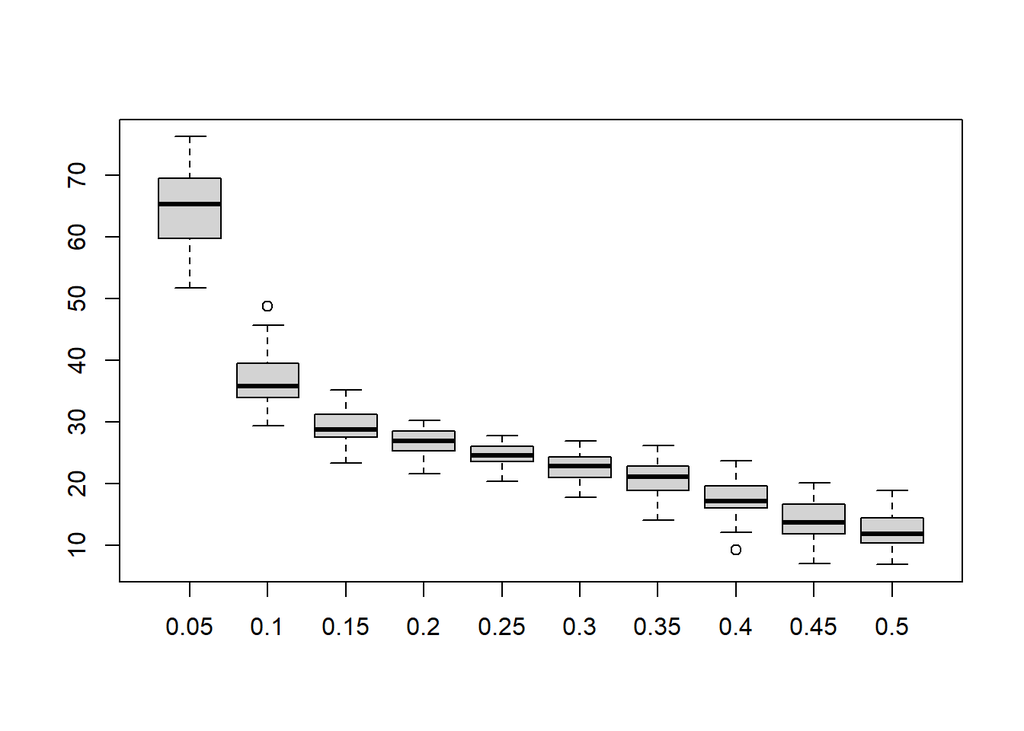

```r
boxplot(profits.lda, names = seq(0.05,0.5,0.05))
```

```r
apply(profits.lda,2,median)
```

```
##  [1] 65.30499 35.84104 28.82625 26.95009 24.63031 22.87431 21.13678 17.24584
##  [9] 13.77079 11.89464
```

Now, let’s try to optimize the threshold but with the Logistic Regression

```r
profits.glm = matrix(NA, 50, 10)

j=0
suppressWarnings(
for (threshold in seq(0.05,0.5,0.05)){
  j = j+1
  for (i in 1:50){
  sp = createDataPartition(train_data2$Price, p =0.75, list = F)
  train_data_op = train_data2[sp,]
  test_data_op = train_data2[-sp,]

  glm_optim = glm(Price~., data = train_data2, family = binomial)

  prob = predict(log_reg, type = "response", newdata = test_data2)

  prob[prob > threshold] = levels(train_data_op$Price)[2]
  prob[prob != levels(train_data_op$Price)[2]] = levels(train_data_op$Price)[1]
  prob= as.factor(prob)

  conf_glm = confusionMatrix(prob, test_data_op$Price)$table
  profits.glm[i,j] = sum(as.vector(conf_glm)*benef.smartphone)/sum(conf_glm)
  }
}
)
apply(profits.glm,2,median)
```

```
##  [1] 68.22222 47.07407 35.92593 30.07407 28.22222 24.44444 20.96296 16.85185
##  [9] 14.59259 11.85185
```

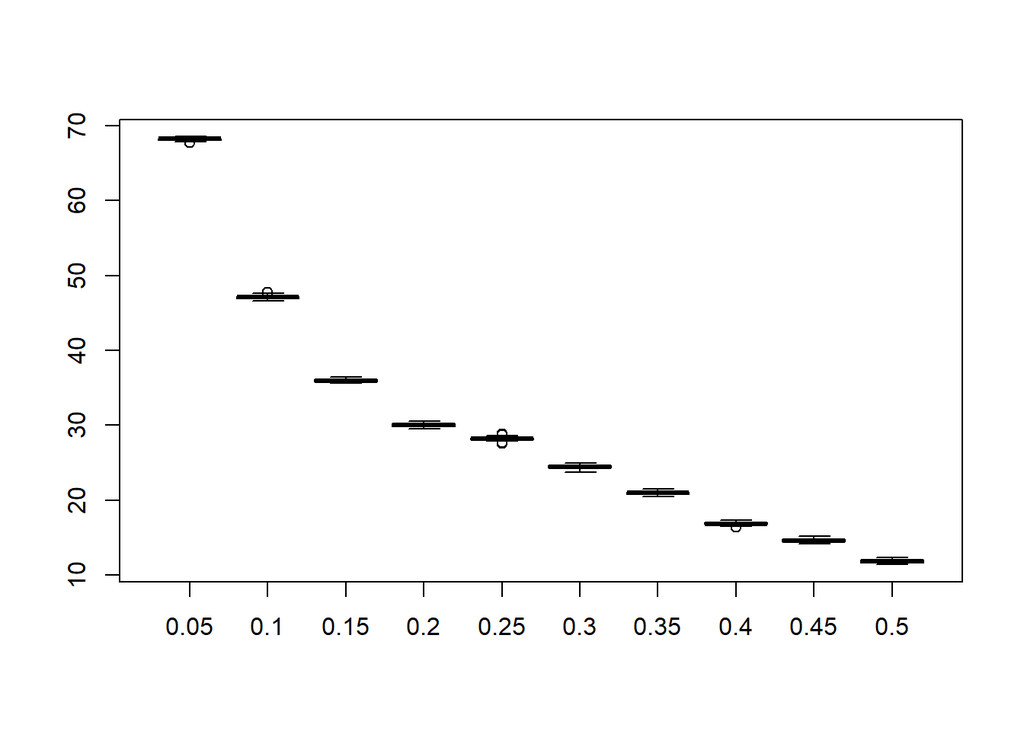

```r
boxplot(profits.glm, names = seq(0.05,0.5,0.05))
```

So finally the bet threshold for both methods are 0.05.

## DECISION TREES

For a first approach of our file information, we’ve made a decision tree of the whole data set, so we can begin to understand the relations between the predictors with the response and get a rough idea of the accuracy our future predictions can reach.

```r
library(rpart); library(rpart.plot)
tree1 = rpart(Price~., data, method = "class", control = rpart.control(minsplit = 25, cp = 0.01, maxdepth = 8))
tree1$variable.importance
```

```
##           Resolution.y           Resolution.x               RAM..MB.
##             215.432063             194.658772             120.043698
##  Internal.storage..GB.           both_cameras              Processor
##             117.949222             106.446566              88.836799
##   Screen.size..inches.           Front.camera         Number.of.SIMs
##              38.758775              20.331279              12.380253
##            Rear.camera Battery.capacity..mAh.       Operating.system
##              11.070811               9.256632               4.493609
```

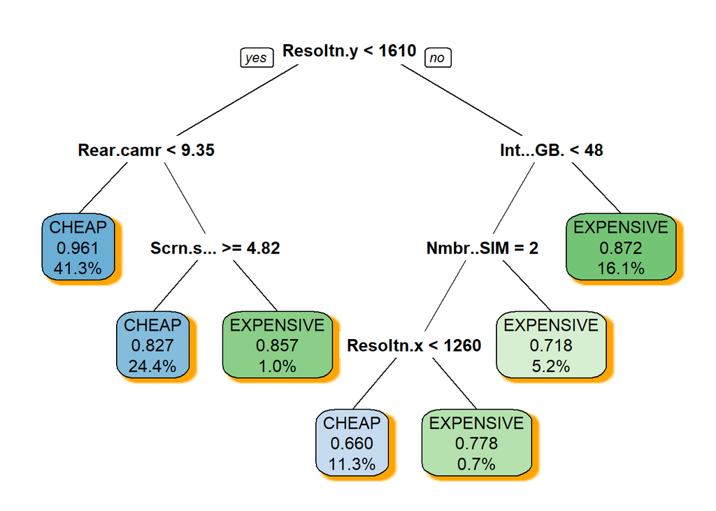

```r
prp(tree1, type = 0, extra = 108, shadow.col="orange", digits = 3, roundint = FALSE,
                 faclen = 8, box.palette = "auto", varlen = 9)
```

In this case the variable ‘Resolution.y’ is the most important and that’s why it composes the first node, because it is the most influential variable in our prediction having the responsabillity of the first split.

The tree splits in several branches, depending on the parameters (min. split, complexity,max depth…). Depending on the number of observations of a variable that fulfill the condition, it will derive into leaves, with their correspondent prediction (EXPENSIVE or CHEAP), or nodes, with new split conditions.

With the variable important plot we can see the importance in this tree. As I have explained, screen resolution in y axis is one of the main things to consider when classifying with this tree.

It is significant to point out, how 40 % of the data is classified as cheap just because of the resolution.y and rear camera.

Trying with different combination of hyper parameters we can reach different accuracies:

```r
library(caret)

caret.tree = train(Price~.,
                   data = train_data2,
                   method = "rpart",
                   control = rpart.control(minsplit = 30),#maxdepth = 10
                   trControl = trainControl(method = "cv", number = 7),
                   tuneLength = 50)
caret.tree
```

```
## CART
##
## 1084 samples
##   18 predictor
##    2 classes: 'CHEAP', 'EXPENSIVE'
##
## No pre-processing
## Resampling: Cross-Validated (7 fold)
## Summary of sample sizes: 929, 930, 929, 929, 929, 929, ...
## Resampling results across tuning parameters:
##
##   cp           Accuracy   Kappa
##   0.000000000  0.8201209  0.5424686
##   0.007498207  0.8376324  0.5801443
##   0.014996414  0.8468670  0.5980086
##   0.022494621  0.8468670  0.5970605
##   0.029992828  0.8468670  0.5970605
##   0.037491035  0.8468670  0.5970605
##   0.044989242  0.8468670  0.5970605
##   0.052487449  0.8468670  0.5970605
##   0.059985656  0.8311988  0.5834682
##   0.067483863  0.8099707  0.5474105
##   0.074982070  0.8099707  0.5474105
##   0.082480276  0.8164223  0.5750877
##   0.089978483  0.8164223  0.5750877
##   0.097476690  0.8164223  0.5750877
##   0.104974897  0.8164223  0.5750877
##   0.112473104  0.8164223  0.5750877
##   0.119971311  0.8164223  0.5750877
##   0.127469518  0.8164223  0.5750877
##   0.134967725  0.8164223  0.5750877
##   0.142465932  0.8164223  0.5750877
##   0.149964139  0.8164223  0.5750877
##   0.157462346  0.8164223  0.5750877
##   0.164960553  0.8164223  0.5750877
##   0.172458760  0.8164223  0.5750877
##   0.179956967  0.8164223  0.5750877
##   0.187455174  0.8164223  0.5750877
##   0.194953381  0.8164223  0.5750877
##   0.202451588  0.8164223  0.5750877
```

[output cut: 10 more lines]

```
##   0.284931864  0.8164223  0.5750877
##   0.292430071  0.8164223  0.5750877
##   0.299928278  0.8164223  0.5750877
##   0.307426485  0.8164223  0.5750877
##   0.314924692  0.8164223  0.5750877
##   0.322422899  0.8164223  0.5750877
##   0.329921106  0.8164223  0.5750877
##   0.337419313  0.8164223  0.5750877
##   0.344917520  0.7943025  0.4788939
##   0.352415727  0.7943025  0.4788939
##   0.359913934  0.7767910  0.3919857
##   0.367412141  0.7767910  0.3919857
##
## Accuracy was used to select the optimal model using the largest value.
## The final value used for the model was cp = 0.05248745.
```

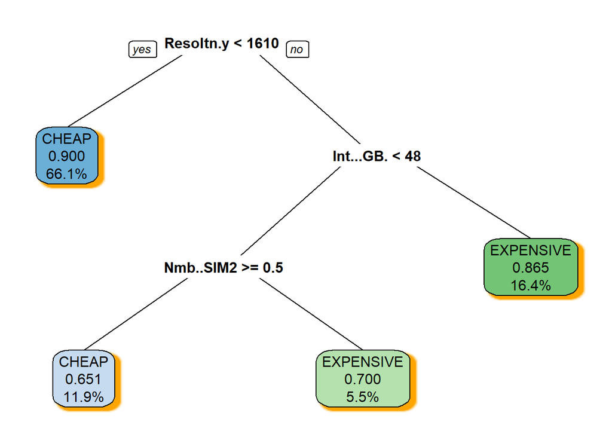

```r
#plotting the final model chosen by the caret algorithm.
prp(caret.tree$finalModel, type = 0, extra = 108, shadow.col="orange", digits = 3, roundint = FALSE,
                 faclen = 8, box.palette = "auto", varlen = 9)
```

```r
prob_tree = predict(caret.tree, test_data2, type = "prob")

threshold = 0.05

tree_pred = rep("CHEAP", nrow(test_data2))
tree_pred[which(prob_tree[,2] > threshold)] = "EXPENSIVE"

conf_tree = confusionMatrix(as.factor(tree_pred), test_data2$Price)$table
conf_tree
```

```
##            Reference
## Prediction  CHEAP EXPENSIVE
##   CHEAP         0         0
##   EXPENSIVE   192        78
```

```r
tree_benefits = sum(benef.smartphone*as.vector(conf_tree))/sum(conf_tree)
tree_benefits
```

```
## [1] 109.5556
```

The tree achieved is really similar to the first one, so we can say that the initial approach was not that far from the final caret analysis.

## Random Forest:

Although the model achieved with the decision trees algorithm has a correct performance, it can be improved using the Random Forest algorithm.

This model collects a defined number of trees “N” with several different splits and the final prediction of the Random Forest will be the majority of the final predictions of each of the trees when each data passes through them.

Here, we are going directly to compute the “best model” of the random forest, trying to reach the best for the model by optimizing a function:

```r
Benefits = function(data, lev =  NULL, model = NULL){
  prediction = data$pred
  true_values = data$obs
  conf= confusionMatrix(prediction,true_values)$table
  returning = sum(benef.smartphone*as.vector(conf))/sum(conf)
  names(returning) = "Benefits"
  return(returning)
}
```

Once the function we want to center the analysis is done it is implemented in the training

```r
rf_model = train(Price ~., method = "rf", data = train_data2, preProcess = c("center", "scale"), cutoff=c(0.75,0.25),tuneGrid = expand.grid(mtry=c(6,8,10,12,14)),ntree = 300, metric = "Benefits", maximize = T, trControl = trainControl(method = "cv", number = 5, classProbs = TRUE, summaryFunction = Benefits, verboseIter=T))
```

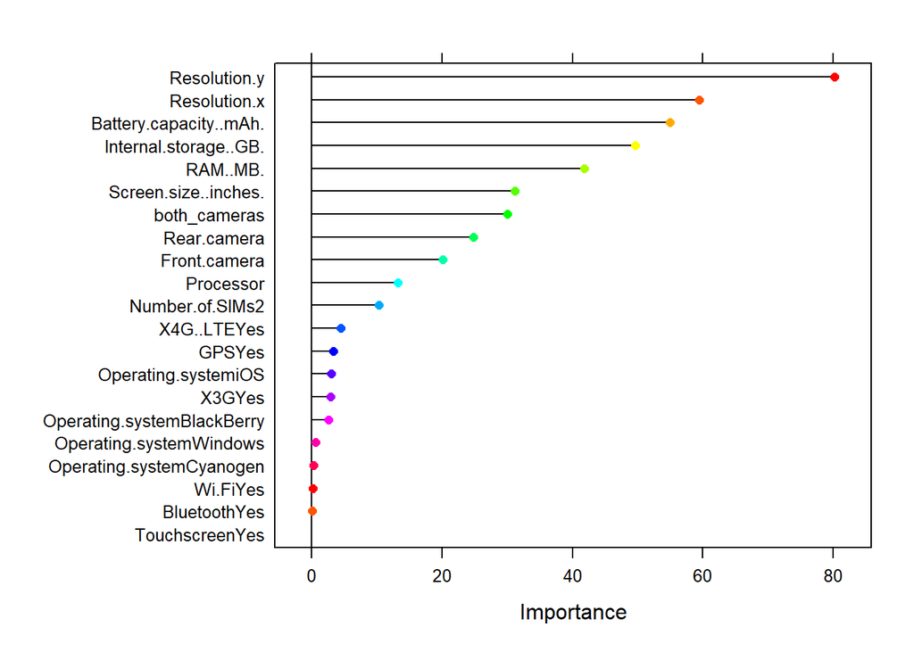

```r
plot(varImp(rf_model, scale = F), col = rainbow(18))
```

They measure the importance within the MeanDecreaseGini which is a metric that computes the mean of the loss in node impurity of a variable. This successfully measures the importance of the variables in estimating the value of Price (independent variable) for all the trees that make up the forest. The larger the average decrease in the Gini coefficient, the higher the importance of the variable.

(Node impurity will be the lowest if all the results are the same (for example, if in Resolution.y split, all the data passing through that node are bigger than 1600, the node impurity will be 0. In contrast, if we have more cases than only “bigger than 1600” resolution, the node impurity will increase.)

In the maximization of our prediction we obtained that the most important variable is still Resolution.y(as in the decision tree method).

Analysing this hyperparameter with RandomForest library we obtained:

```r
library(randomForest)
```

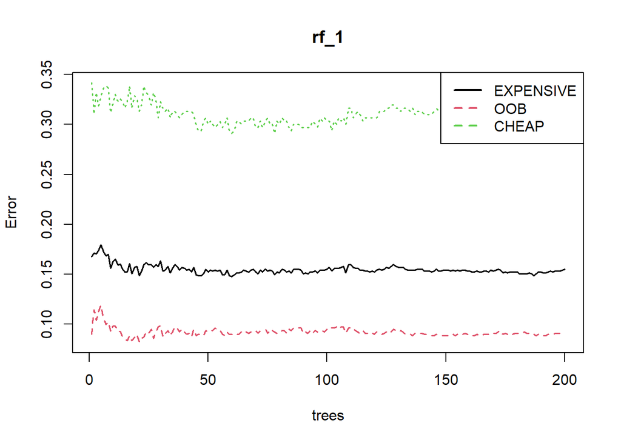

```r
rf_1=randomForest(Price ~., data = train_data2, ntree = 200,mtry = 14, method = "class")
plot(rf_1, col = c(1,2,3),lwd = 1.6)
legend(x = "topright",
       legend = c("EXPENSIVE","OOB","CHEAP"),
       lty = c(1,2,2),
       col = c(1,2,3),
       lwd = 2)
```

Moreover, it is needed to clear out the OOB line. OOB is the number of correctly performed predictions of the Out of Bag rows. By way of clarification, the least errors the model have, the most accurate it will be.

OOB rows are the ones that were not chosen in the sampling of data, therefore, their predictions could not perform correctly.

```r
threshold = 0.05
prob_rf=predict(rf_model, newdata = test_data2, type = "prob")

rf_pred = rep("CHEAP", nrow(test_data2))
rf_pred[which(prob_rf[,2] > threshold)] = "EXPENSIVE"

conf_rf = confusionMatrix(as.factor(rf_pred), test_data2$Price)$table

rf_benefits = sum(benef.smartphone*as.vector(conf_rf))/sum(conf_rf)
rf_benefits
```

```
## [1] 51.74074
```

## Gradient Boosting

This model combines a group of weak machine learning models to create a stronger predictive models.

with gbm function factors are need to be exchanged to 0(cheap) and 1(Expensive), so:

```r
#It does not work really well
gbm_1 = gbm::gbm(ifelse(train_data2$Price=="CHEAP",0,1)~., data = train_data2, distribution = "bernoulli",
                 n.trees = 300, shrinkage = 0.01, interaction.depth = 2, n.minobsinnode = 8)

prob_gbm=predict(gbm_1, newdata = test_data2, n.trees = 300,type = "response")

gbm_pred = rep("CHEAP", nrow(test_data2))
gbm_pred[which(prob_gbm > 0.15)] = "EXPENSIVE" #Considered the threshold of the ROC curve in this case

conf_gbm = confusionMatrix(as.factor(gbm_pred), test_data2$Price)$table

conf_gbm
```

```
##            Reference
## Prediction  CHEAP EXPENSIVE
##   CHEAP       143        11
##   EXPENSIVE    49        67
```

```r
gbm_benefits = sum(benef.smartphone*as.vector(conf_gbm))/sum(conf_gbm)
gbm_benefits
```

```
## [1] 36.22222
```

With grid expansion the model is really complex so the execution is really large and that is why it is commented:

```r
# grid_for_gb = expand.grid(eta = c(0.01, 0.001), min_child_weight = c(1,3,6),max_depth = c(2, 4, 6,8,10),
#                            colsample_bytree = c(0.2, 0.,3,0.4,0.5),subsample = 1,nrounds = c(500,1000),gamma = 1)
#
# gb_model = train(Churn ~ .,  data=training,
#                  trControl = trainControl(method = "cv", number = 5, classProbs = TRUE, summaryFunction = Benefits, verboseIter=T),metric="EconomicCost",tuneGrid = xgb_grid,preProcess = c("center", "scale"),maximize = TRUE,method = "xgbTree")
#
```

## FINAL CONCLUSION ON CLASSIFICATION

Finally it is finished the process of CLASSIFICATION and the expected benefit of the NAIVE classifier has been positively improved.

A change in those parameters could obviously change the result on the threshold and consequently on the benefits too.

As I said, it is not a real model with real data and it may have no lot of sense but it was only thought to try to see the performing of each algorithm and not the business case deeply.

# REGRESSION

Now, the case settles in Regression, that mainly consists on the combination of features in our dataset by several algorithms to reach a numerical value, so now it is the moment when all those factors created in Price variable are replaced by original prices.

```r
#this change it is not necessary but it is introduced for being able to work with both parts of the project simultaneusly.
data_reg = data
data_r_numeric = data_numeric
data_reg$Price = orig_price
data_r_numeric$Price = orig_price
data_reg$Price = as.numeric(data_reg$Price)
data_r_numeric$Price = as.numeric(data_r_numeric$Price)
```

At first, data splitting for working with continuous prices:

```r
sp_r = createDataPartition(data_reg$Price, p = 0.8, list = FALSE)
train_reg = data_reg[ sp_r,]
test_reg = data_reg[-sp_r,]
```

So as a remainder, let’s see the correlation that conserve each of the features within the objective var.

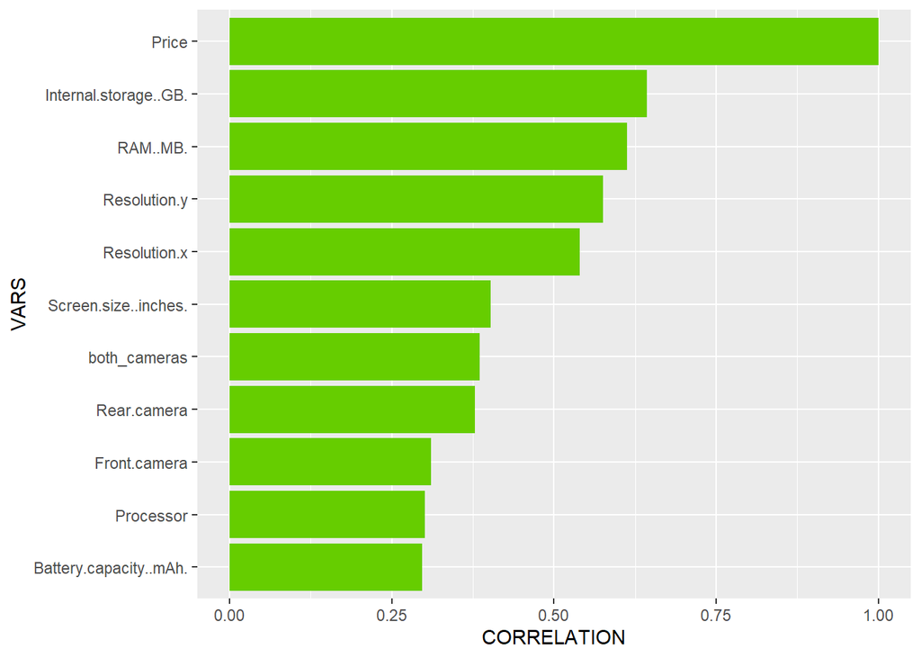

```r
ggplot()+aes(x=cor(data_numeric)["Price",], y = reorder(names(cor(data_numeric)["Price",]),
                                                         cor(data_numeric)["Price",])) +
  geom_col(fill = "chartreuse3")+labs(x="CORRELATION",y="VARS")
```

The correlation within all the variables in the dataset are:

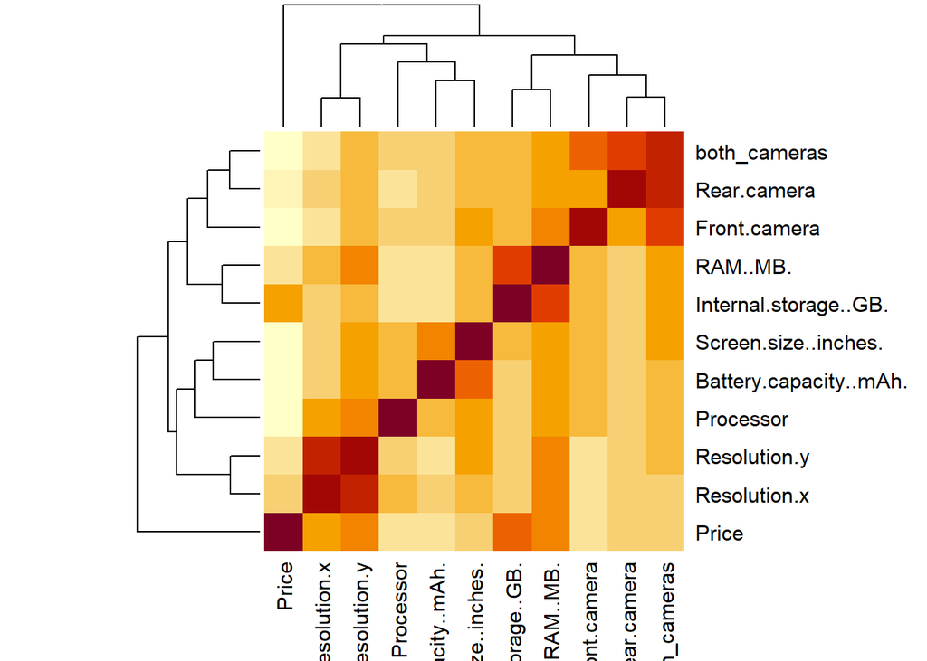

```r
cor_mat = cor(data_r_numeric)
heatmap(cor_mat)
```

There are some realtions that can be clearly watched in this graph by the dendrogram, such as the cameras, resolution and ROM with RAM.